# An Analysis of SAP Concur Expenditure for 2018 (Dummy Data)

Jayashree Raman

March 6, 2019

## Highlights/Key Insights Learned from the Data Set:

- The **Manufacturing Vertical saw an unusually high Total Expenditure in Q2 2018** (could be because of an outlier, or actual expenditure). The Mileage Spend for manufacturing however wasn’t skewed by this outlier
- **Business Services** saw a steady and **the highest average growth** in Mileage Spend in 2018 overall (1.33% increase), followed by **Healthcare Service Providers (0.98%)** and **Higher Education (0.29%)**, indicating that these verticals may be prone to fraudulent expense reporting, and also that they may need assistance with the optimization of their travel and expense program
- Out of **23 verticals in total, 12 saw a decrease in their average mileage spend**, which may be an indicator of a well managed travel expense program, under control
- The **State and Local Government Vertical saw the steepest decline in the Mileage Spend** in 2018 overall

# Computing Percentage Mileage Spend each Quarter

## Analysis for Total Concur Spend

### Total Mileage Expenditure by Concur ENT

| Quarters | SpendValue |
| --- | --- |
| Q1_2018_Mileage_Spend | 506342471 |
| Q2_2018_Mileage_Spend | 751498817 |
| Q3_2018_Mileage_Spend | 697754641 |
| Q4_2018_Mileage_Spend | 700348406 |

### Overall Total Expenditure by Concur ENT

| Quarters | SpendValue |
| --- | --- |
| Q1_2018_Total_Spend | 19753802615 |
| Q2_2018_Total_Spend | 736657269387 |
| Q3_2018_Total_Spend | 22923761012 |
| Q4_2018_Total_Spend | 24552784591 |

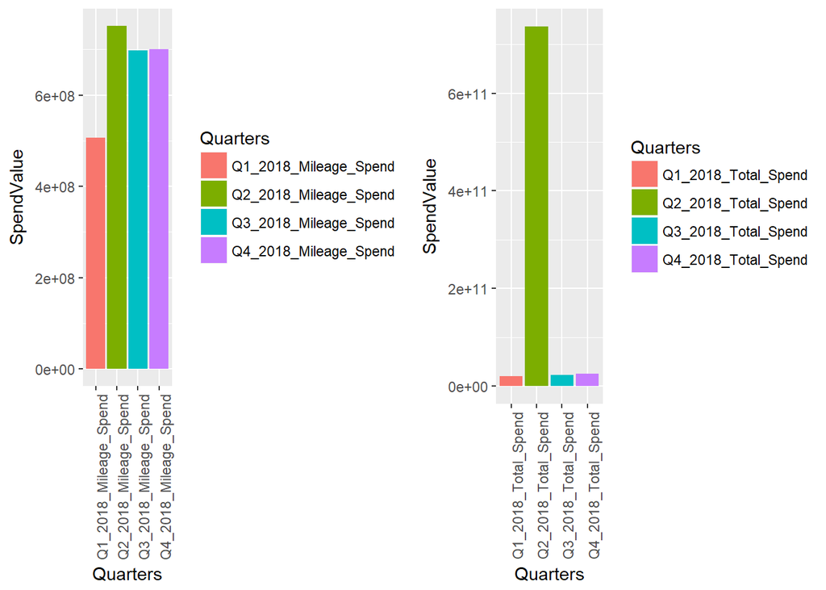

## Trend of Mileage Spend as a percentage of Total Spend for Concur ENT, Quarter on Quarter (QoQ)

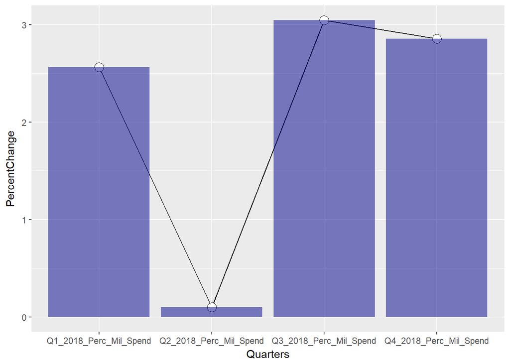

### Mileage Spend Trend for Each Vertical in 2018 (Aggregate/Average)

> The average percentage change has been calculated by taking the sum of the differences between the percentage shares for each quarter, and dividing the sum by 3.

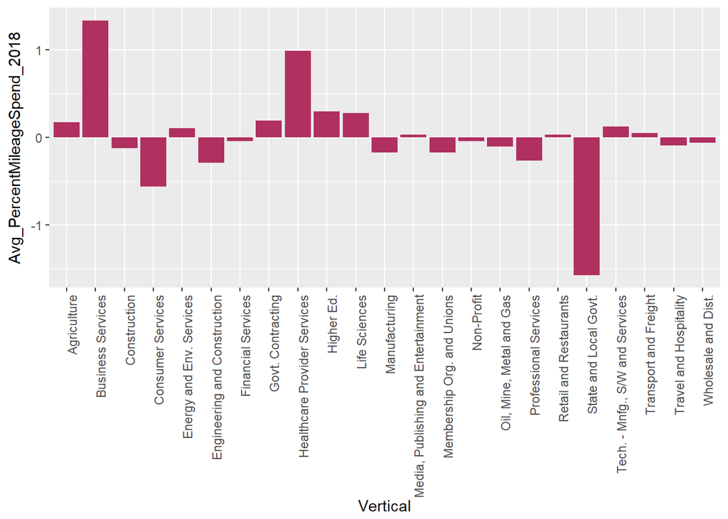

## Quality Check for Percentage Spend Column

| Verticals.Industry | Percentage_Spend | actual_percentage_spend | diff_in_perc_spend |
| --- | --- | --- | --- |
| Agriculture | 0.0371485 | 0.0268070 | -0.0103415 |
| Business Services | 0.0348461 | 0.0411750 | 0.0063289 |
| Construction | 0.0161458 | 0.0158476 | -0.0002982 |
| Consumer Services | 0.0381075 | 0.0277850 | -0.0103224 |
| Energy and Env. Services | 0.0388297 | 0.0362585 | -0.0025713 |
| Engineering and Construction | 0.0251391 | 0.0230360 | -0.0021031 |
| Financial Services | 0.0362392 | 0.0353062 | -0.0009330 |
| Govt. Contracting | 0.0289597 | 0.0281998 | -0.0007599 |
| Healthcare Provider Services | 0.0936223 | 0.1156135 | 0.0219912 |
| Higher Ed. | 0.0214768 | 0.0253604 | 0.0038835 |
| Life Sciences | 0.0169554 | 0.0159042 | -0.0010512 |
| Manufacturing | 0.0005217 | 0.0007477 | 0.0002261 |
| Media, Publishing and Entertainment | 0.0130765 | 0.0130977 | 0.0000212 |
| Membership Org. and Unions | 0.0226660 | 0.0232508 | 0.0005848 |
| Non-Profit | 0.0340647 | 0.0310162 | -0.0030485 |
| Oil, Mine, Metal and Gas | 0.0243676 | 0.0259374 | 0.0015698 |
| Professional Services | 0.0312821 | 0.0301614 | -0.0011206 |
| Retail and Restaurants | 0.0450244 | 0.0473044 | 0.0022800 |
| State and Local Govt. | 0.1027024 | 0.1063438 | 0.0036414 |
| Tech. - Mnfg., S/W and Services | 0.0292477 | 0.0269261 | -0.0023216 |
| Transport and Freight | 0.0211457 | 0.0216110 | 0.0004653 |
| Travel and Hospitality | 0.0143221 | 0.0142760 | -0.0000461 |
| Wholesale and Dist. | 0.0312207 | 0.0286384 | -0.0025823 |
| Concur ENT | 0.0027972 | 0.0033039 | 0.0005067 |

> We observe that there are very minute differences in the reported and actual percentage spends for each Vertical. While these may be small enough by themselves, **it makes a significant impact on the expense statement, since the amount spent is in billions/trillions.**

# Trends in Mileage Spending vs Total Spending, by Vertical

### Change in Mileage Spending, and Distribution of Mileage Spending, by Vertical

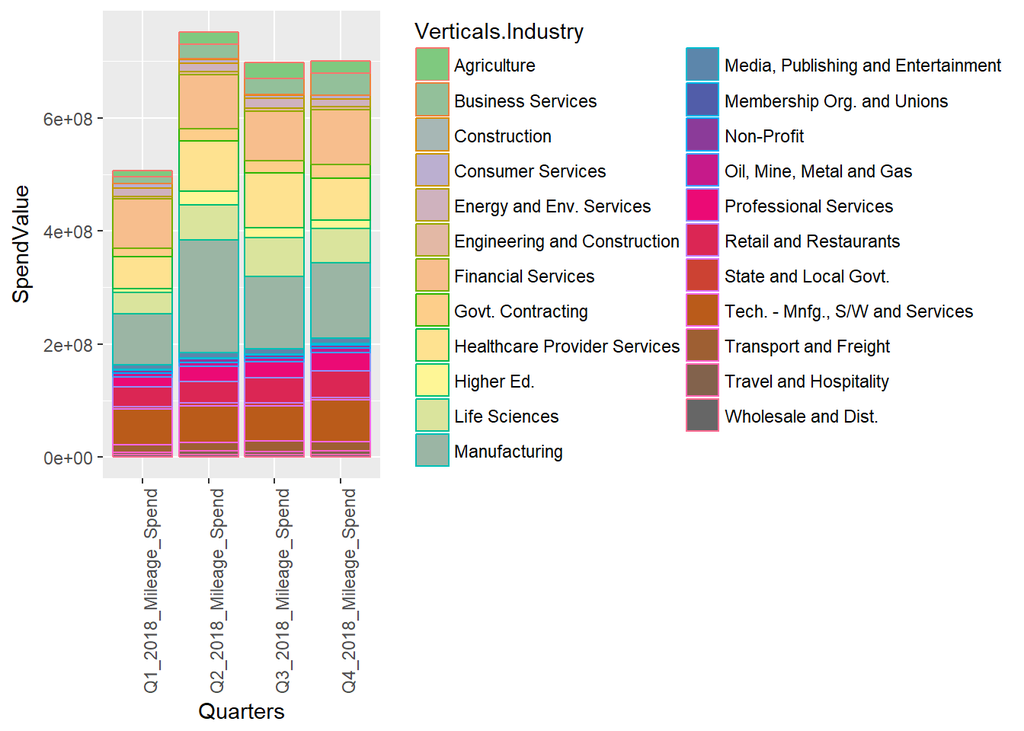

### Verticals, ordered by the Mileage Expenditure, for each quarter in 2018

#### Trend in the Percentage Mileage Share of Total Expenditure, By Vertical, QoQ

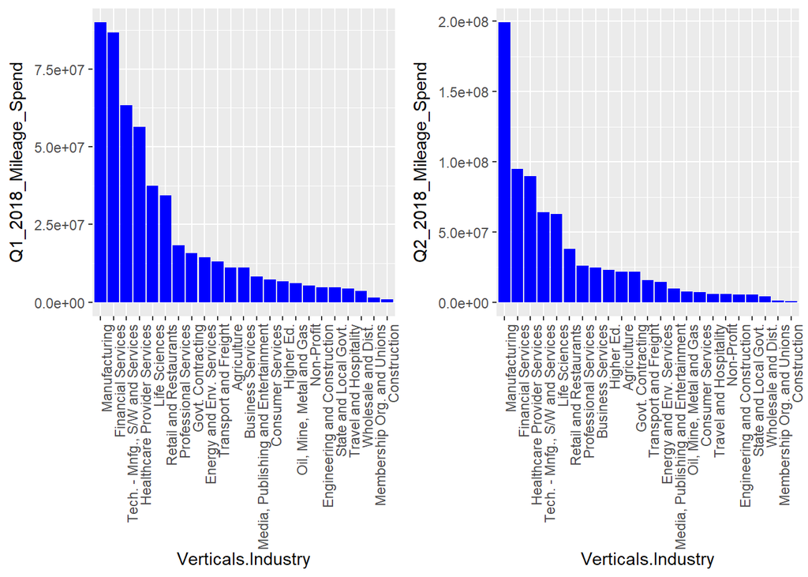

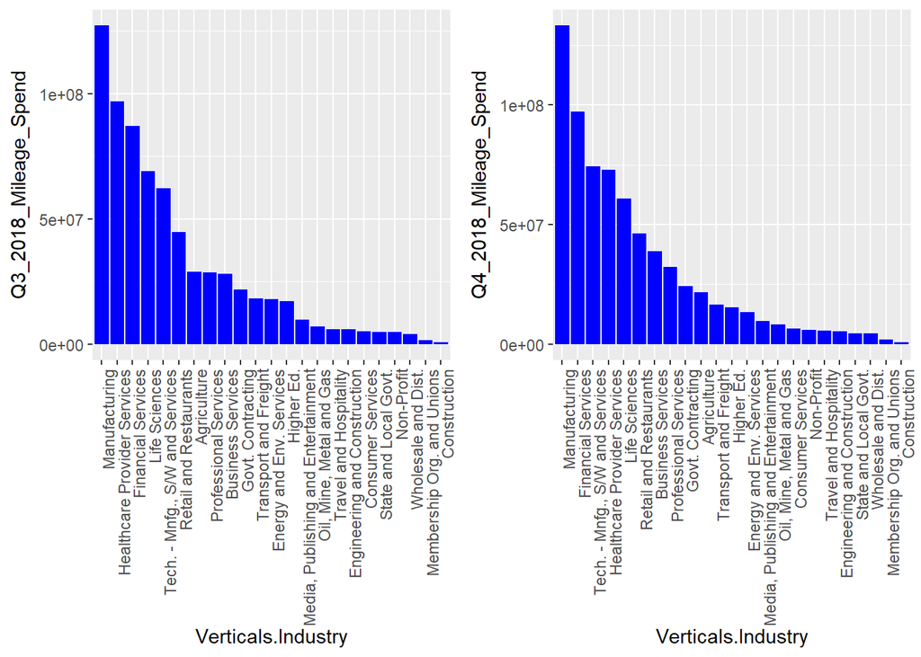

> Key Observations:  
> - Manufacturing has the highest mileage spend in every quarter  
> - It is followed by Financial Services, except in Q3, when Healthcare Provider Services take over the second place  
> - Healthcare Provider Services and Life Services Spending on mileage undergo a huge jump from Q2 to Q3  
> - Construction and Membership Orgs and Unions have the lowest Mileage spend in all four quarters of 2018  
> - For the remaining verticals, the average spend on mileage remains more or less in the same range

### Mileage Spend, as a percentage of Total Spend, By Vertical, QoQ

#### Q1 - 2018

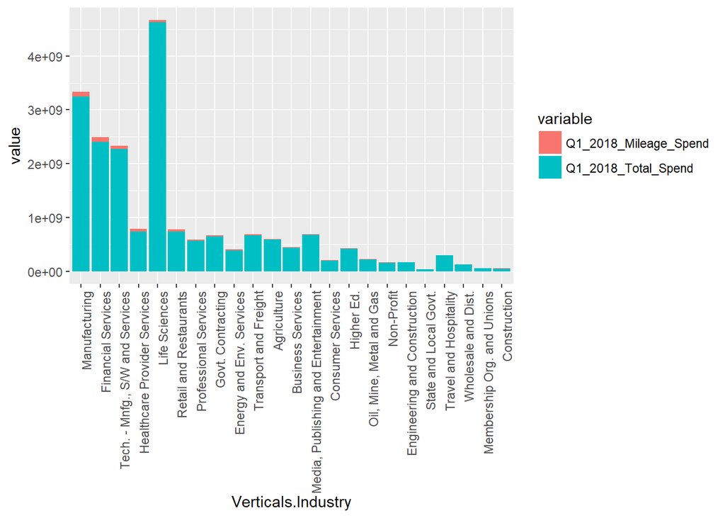

> Key Observations: - We see that Life Sciences has the highest total expenditure, but in terms of mileage spending it is ranked 5th  
> - Manufacturing has the second highest Total Expenditure, and highest Mileage Expenditure  
> - An important point to note is that Healthcare Provider Services have a significantly small Total Expenditure, but high Mileage Expenditure (7%)  
> - The highest percentage share of Mileage Expenditure to Total Expenditure is for the State & Local Governments, a whopping 14%  
> - Business Services saw a steady increase 2.54% in its Mileage Expenditure

#### Q2 - 2018

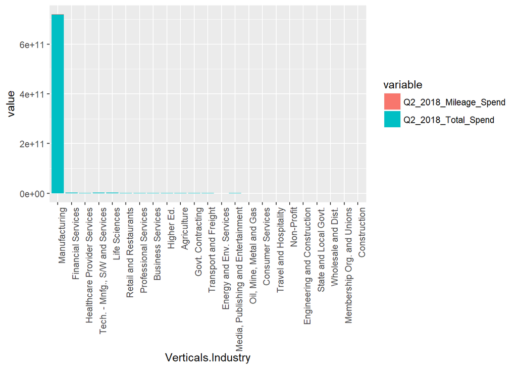

> Key Observations:  
> - On an inital glance, we see Manufacturing take over all other verticals in terms of Total Expenditure, and hence we cannot see the Mileage Spend of the other verticals in the plot at all -This could either be because of **the presence of an outlier** in the field, or unusually high total expenditure for manufacturing in Q2. In either case it impacts the analysis of the data  
> - We can remove Manufacturing from the set for the time being, and look at other verticals

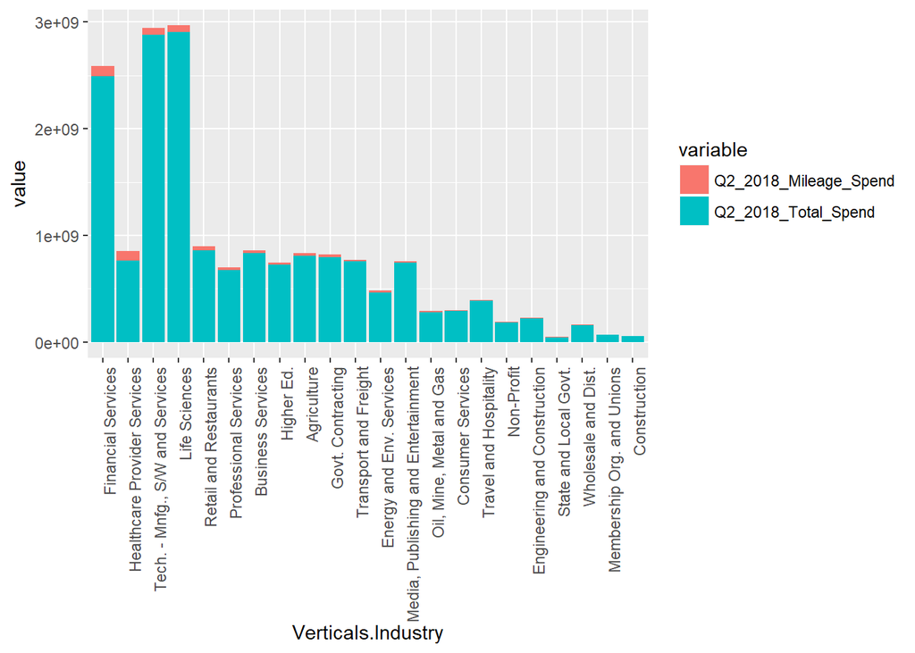

#### Q3 - 2018

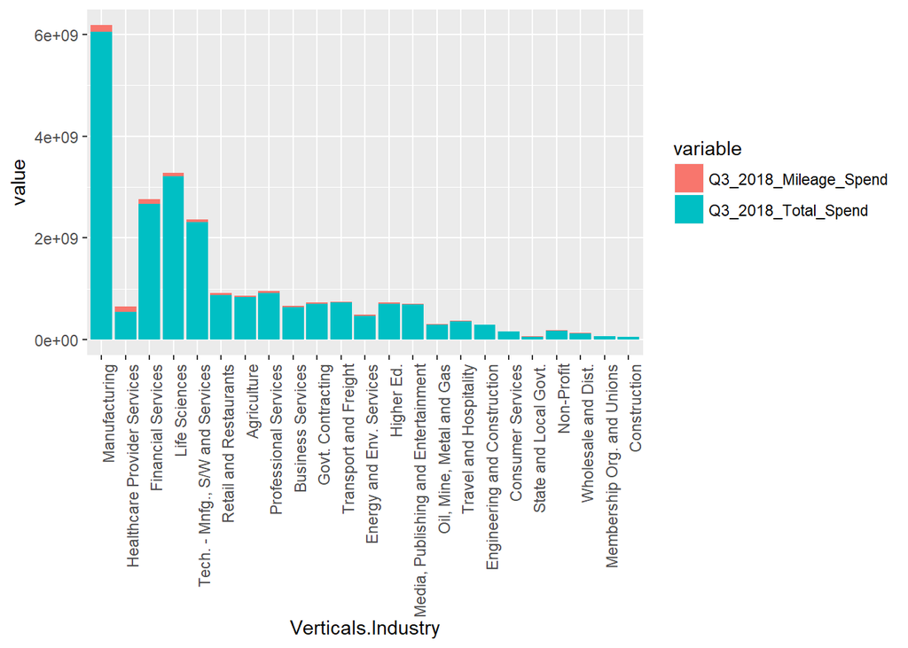

> Key observations:  
> - The pattern pretty much remains the same, except for the following–  
> - The **Total Expenditure for Life Sciences falls by a significant amount, but it still ranks 4th in terms of Mileage Spend**  
> - Manufacturing again sees the **highest Total Spend, and highest Mileage Spend**  
> - Healthcare Provider Services see a jump in Mileage Spend from 11% to 17%, putting them in the second position for Mileage Spend (**could be anomalies in the data/system, or fraudulent claims submitted**)  
> -State & Local Government Expenditure on Mileage see a fall from **12% to 8.5%**  
> - Business Services saw a steady increase of 4.4% from 2.98% in their Mileage Spend

#### Q4 - 2018

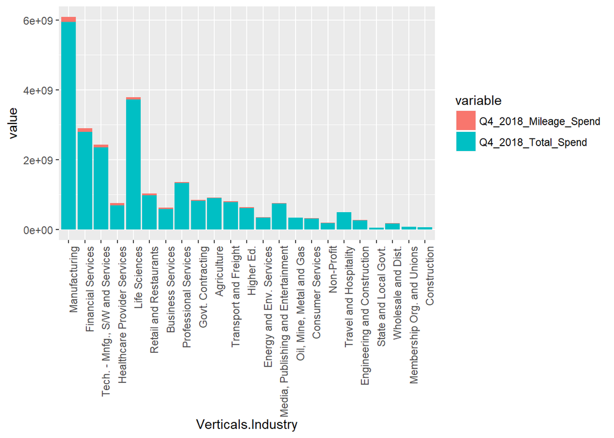

> Key Observations:  
> - State & Local Govt Mileage Spend goes up by 1%  
> - Healthcare Provider Services see a reduction in % Mileage Spend from 17% to 10%  
> - Business Services saw a big jump in Mileage Spend from 4.4% to 6.5% in their Mileage Spend

### Line Chart depicting the trends of Mileage Spend Percentages for each Vertical

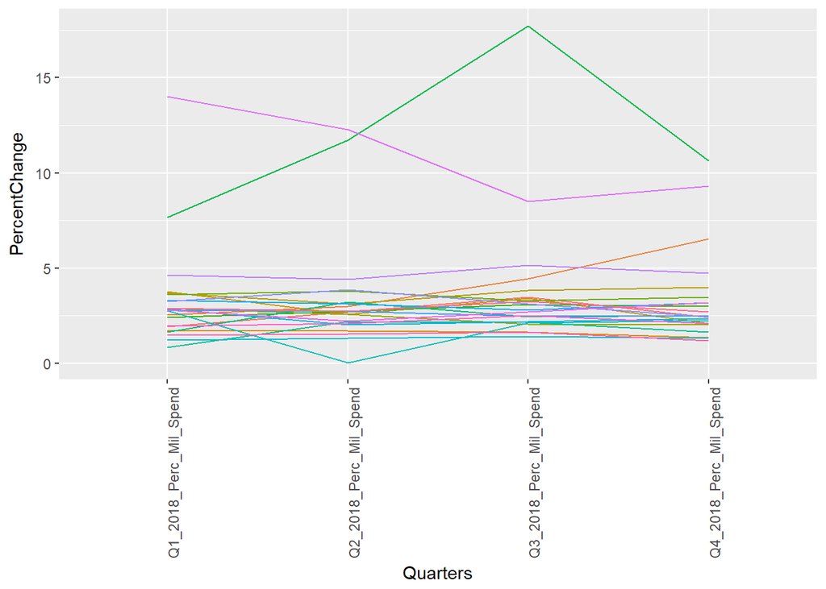

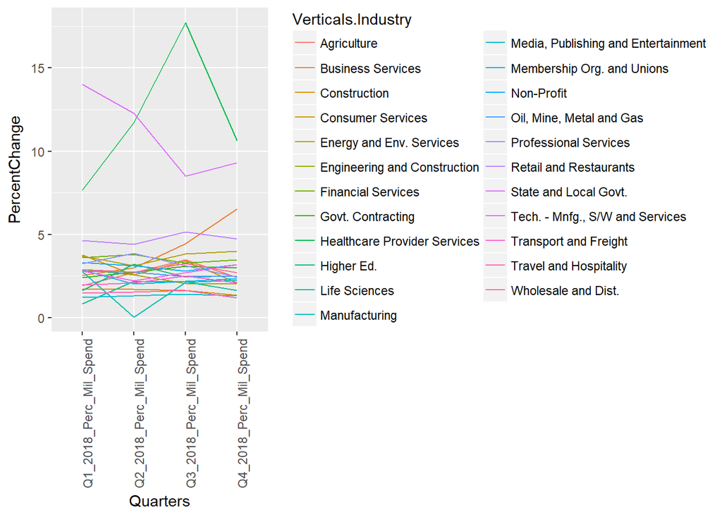

> The trend lines plot confirms our insights observed in the QoQ plots, some of which are:  
> - Healthcare Provider services see the sharpest/highest percentage change in Mileage spend  
> - The Manufacturing trend line hits bottom rock in Q2, mainly due to a really high Total Expenditure  
> - State and Local Government vertical starts at a high share, but dips steadily till Q3, and rises slightly in Q4  
> - The line trend for Business Services shows a steady incline/ascent, as confirmed by our observation

### Summary Table

> The average percentage change has been calculated by taking the sum of the differences between the percentage shares for each quarter, and dividing the sum by 3.

| Vertical | Q1 %MileageSpend | Q2 %MileageSpend | Q3 %MileageSpend | Q4 %MileageSpend | Avg_PercentMileageSpend_2018 |
| --- | --- | --- | --- | --- | --- |
| Agriculture | 1.9113611 | 2.7045786 | 3.482302 | 2.419887 | 0.1695088 |
| Business Services | 2.5412582 | 2.9896635 | 4.422064 | 6.544413 | 1.3343849 |
| Construction | 1.7082827 | 1.7041632 | 1.615707 | 1.342477 | -0.1219353 |
| Consumer Services | 3.7511500 | 2.5560649 | 3.413304 | 2.068078 | -0.5610239 |
| Energy and Env. Services | 3.6911622 | 3.1194500 | 3.811129 | 3.995821 | 0.1015528 |
| Engineering and Construction | 2.8926908 | 2.5537552 | 2.034645 | 2.016500 | -0.2920635 |
| Financial Services | 3.6105287 | 3.8047180 | 3.260897 | 3.475264 | -0.0450884 |
| Govt. Contracting | 2.4176165 | 2.7366381 | 3.097124 | 2.983418 | 0.1886005 |
| Healthcare Provider Services | 7.6618746 | 11.7383289 | 17.739538 | 10.624490 | 0.9875384 |
| Higher Ed. | 1.6231195 | 3.1950454 | 2.423221 | 2.510854 | 0.2959114 |
| Life Sciences | 0.8078357 | 2.1657439 | 2.145733 | 1.634619 | 0.2755946 |
| Manufacturing | 2.7679847 | 0.0276827 | 2.098268 | 2.236821 | -0.1770546 |
| Media, Publishing and Entertainment | 1.2229084 | 1.3133893 | 1.398376 | 1.303210 | 0.0267672 |
| Membership Org. and Unions | 2.8646500 | 2.0144992 | 2.190483 | 2.335901 | -0.1762498 |
| Non-Profit | 3.3136817 | 3.1179555 | 2.800109 | 3.182505 | -0.0437256 |
| Oil, Mine, Metal and Gas | 2.7780205 | 2.7397139 | 2.454594 | 2.467843 | -0.1033923 |
| Professional Services | 3.2337203 | 3.8597578 | 3.104598 | 2.432889 | -0.2669439 |
| Retail and Restaurants | 4.6214133 | 4.4158086 | 5.146903 | 4.718886 | 0.0324909 |
| State and Local Govt. | 14.0167437 | 12.2887007 | 8.490819 | 9.297165 | -1.5731928 |
| Tech. - Mnfg., S/W and Services | 2.7893412 | 2.2253236 | 2.701667 | 3.163636 | 0.1247650 |
| Transport and Freight | 1.9570856 | 2.0868198 | 2.500107 | 2.092704 | 0.0452063 |
| Travel and Hospitality | 1.4569578 | 1.5347633 | 1.636254 | 1.172944 | -0.0946713 |
| Wholesale and Dist. | 2.8773902 | 2.7377943 | 3.255665 | 2.691762 | -0.0618761 |

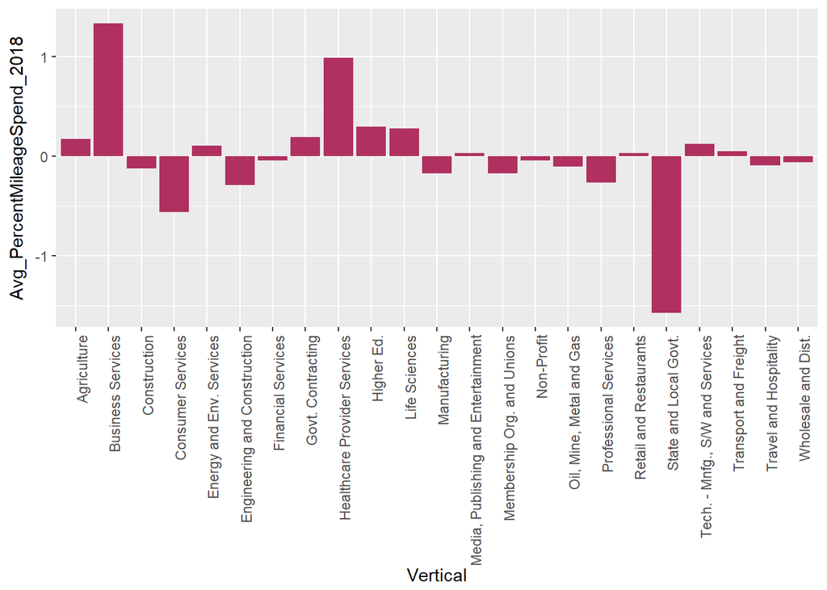

> The above plot gives us a great insight as to how the Mileage Spend fell or rose in 2018, based on Industry Vertical. This can be a great way for SAP Concur to assess which industries/verticals are most profitable, and how to optimize the mileage spends for verticals that are not.

> Other things remaining the same, these can also be used as trends in these verticals, to predict what the mileage expenditure for 2019 could be like.